# ETO5513 Assignment 1

Chenxi Zhang (33475776)

2023-05-20

## Section 2: Research Question

The data being examined in this assignment is to investigate how Australia’s median age and natural growth rate compares to a country that is well known as being in population decline such as Japan.

## Section 3: Dataset Introduction

The dataset “population-growth-rate-vs-median-age.csv” is sourced from https://ourworldindata.org/grapher/population-growth-rate-vs-median-age. It contains variables relating to the growth rate and median age of countries accross a number of years.

```r
kable(tb)
```

| Entity | Code | Year | Growth_Rate | Median_Age | Continent |
| --- | --- | --- | --- | --- | --- |
| Australia | AUS | 1950 | 1.37 | 29.4 | NA |
| Australia | AUS | 1951 | 1.32 | 29.3 | NA |
| Australia | AUS | 1952 | 1.39 | 29.3 | NA |
| Australia | AUS | 1953 | 1.38 | 29.3 | NA |
| Australia | AUS | 1954 | 1.33 | 29.2 | NA |
| Australia | AUS | 1955 | 1.36 | 29.2 | NA |
| Australia | AUS | 1956 | 1.33 | 29.1 | NA |
| Australia | AUS | 1957 | 1.38 | 29.0 | NA |
| Australia | AUS | 1958 | 1.39 | 28.9 | NA |
| Australia | AUS | 1959 | 1.34 | 28.8 | NA |
| Australia | AUS | 1960 | 1.36 | 28.6 | NA |
| Australia | AUS | 1961 | 1.42 | 28.4 | NA |
| Australia | AUS | 1962 | 1.32 | 28.1 | NA |
| Australia | AUS | 1963 | 1.27 | 27.8 | NA |
| Australia | AUS | 1964 | 1.13 | 27.5 | NA |
| Australia | AUS | 1965 | 1.06 | 27.3 | NA |
| Australia | AUS | 1966 | 1.02 | 27.1 | NA |
| Australia | AUS | 1967 | 1.06 | 27.0 | NA |
| Australia | AUS | 1968 | 1.08 | 26.8 | NA |
| Australia | AUS | 1969 | 1.16 | 26.7 | NA |
| Australia | AUS | 1970 | 1.15 | 26.6 | NA |
| Australia | AUS | 1971 | 1.31 | 26.6 | NA |
| Australia | AUS | 1972 | 1.22 | 26.6 | NA |
| Australia | AUS | 1973 | 1.07 | 26.7 | NA |
| Australia | AUS | 1974 | 0.95 | 26.9 | NA |
| Australia | AUS | 1975 | 0.89 | 27.1 | NA |
| Australia | AUS | 1976 | 0.82 | 27.4 | NA |
| Australia | AUS | 1977 | 0.83 | 27.7 | NA |
| Australia | AUS | 1978 | 0.81 | 27.9 | NA |
| Australia | AUS | 1979 | 0.80 | 28.1 | NA |

[output cut: 114 more lines]

## Section 4: Data set description

After filtering the dataset for Australia and Japan, there are 144 data points in total from the year 1950 to 2021. The column names are Entity, Code, Year, Growth_Rate, Median_Age, Continent respectively, and their data types are character, character, numeric, numeric, numeric, character respectively.  
Over this period:  
Australia: Sum of natural growth rate is 64.75 and the average age has increased from 29.4 to 37.  
Japan: Sum of natural growth rate is 36.86 and the average age has increased from 21.2 to 48.4.

Screenshot:

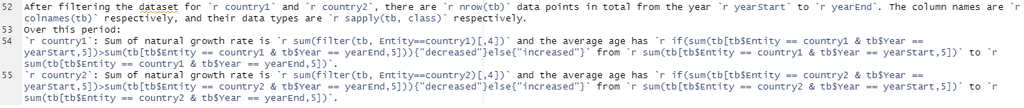

## Section 5: Data summary

```r
tb_grouped = tb %>% group_by(Entity) %>% summarise(data_points = n(),
                                                   start_year = min(Year),
                                                   end_year = max(Year),
                                                   )
knitr::kable(tb_grouped, format="simple", caption="Australia vs Japan Population Growth - Description of Data")
```

Australia vs Japan Population Growth - Description of Data

| Entity | data_points | start_year | end_year |
| --- | --- | --- | --- |
| Australia | 72 | 1950 | 2021 |
| Japan | 72 | 1950 | 2021 |

```r
tb_grouped = tb %>% group_by(Entity) %>% summarise(avg_growth = mean(Growth_Rate),
                                                   start_growth = first(Growth_Rate),
                                                   end_growth = last(Growth_Rate),
                                                   avg_age = mean(Median_Age),
                                                   start_age = first(Median_Age),
                                                   end_age = last(Median_Age),
                                                   )
knitr::kable(tb_grouped, format="simple", caption="Australia vs Japan Population Growth - Summary of Growth and Mean Age")
```

Australia vs Japan Population Growth - Summary of Growth and Mean Age

| Entity | avg_growth | start_growth | end_growth | avg_age | start_age | end_age |
| --- | --- | --- | --- | --- | --- | --- |
| Australia | 0.8993056 | 1.37 | 0.51 | 31.24306 | 29.4 | 37.0 |
| Japan | 0.5119444 | 1.73 | -0.61 | 34.61667 | 21.2 | 48.4 |

The summary table shows that there are 72 data points collected for both Australian and Japan, which represents 1 data every year containing the growth rate and Mean Age for every year between the years 1950 and 2021. Based on the summary of population growth rates and population average age, Japan started with a lower average compared to Australia, however ended with a much **higher** average age. This is explained by the population growth which for Japan started higher but ended in population decline, while Australia started with a lower growth rate, it still ended in positive territory.

## Section 6: Visualisations

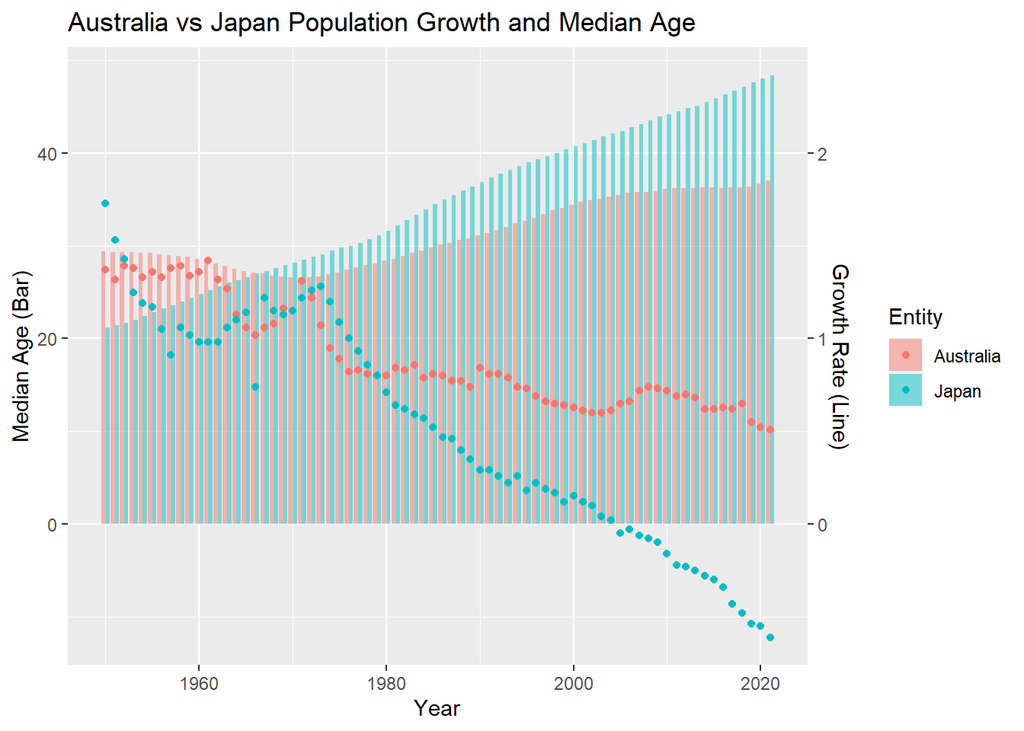

```r
graph1 = ggplot(tb)+
  geom_bar(aes(x=Year, y=Median_Age, fill=Entity), stat="identity",position = position_dodge(),alpha = 0.5)+
  #geom_line(aes(x=Year, y=20*Growth_Rate, color=Entity), stat="identity", size=2)+
  geom_point(aes(x=Year, y=20*Growth_Rate, color=Entity), stat="identity")+
  labs(title="Australia vs Japan Population Growth and Median Age", x="Year", y="Median Age (Bar)")+
  scale_y_continuous(sec.axis=sec_axis(~./20,name="Growth Rate (Line)"))
graph1
```

- Japan’s median age became higher compared to Australia from the mid 1960’s
- While population growth in both countries has generally been declining from 1950, major divergence occurs from the late 1970s where year on year decrease in Japan’s population growth rate is seen, even after it first enters negative growth in 2005.
- The difference between the rate of population growth rate reduction between Australia and Japan can be seen in the difference between respective gradient coefficient in the linear regression of the growth rate line. For Australia, the gradient of the growth rate line is -0.0123128. For Japan, the gradient of the growth rate line is -0.0276005. The rate of growth rate reduction in Japan is more than doubled that of Australia.

## Section 7: Conclusion

Based on the data of population growth and median age between 1950 and 2021, while Australia has witnessed a steady decrease in population growth since the early 1960, the year on year decrease in growth over the past few decades has been relatively mild compared to Japan where population decline has become a major issue.  
From 1950 when the measure was first available, Japan started with a much lower median age and a higher population growth rate. However after a period of relative stability (and even growth over some years) until the 1970s, year on year decrease in growth rate begun to accelerate, resulting in negative growth from the mid 2000s. Referring to the co-efficient value corresponding to the rate of decrease in growth rate, Japan’s rate of growth rate decrease is more than doubled that of Australia over the period 1950 to 2021. This is a major contributing factor of population aging in Japan. Australia on the other hand have fared better with a significantly lower year on year decrease in growth rate and have yet to experience negative growth.  
The data examined in this report highlight existing policy challenges for Japan and other similar nations currently experiencing negative population growth and significant aging of population. There’s are currently no resolution in sight as a recovery in population growth is yet to be seen. While Australia is currently not in population decline, the rate of population decrease appears steady and it is a strong possibility in the future.